# hw3

Shawn Ye

## APIS

#### 1

```r
# Downloading the website
website <- xml2::read_html("https://pubmed.ncbi.nlm.nih.gov/?term=sars-cov-2+trial+vaccine")
# Finding the counts
counts <- xml2::xml_find_first(website, "/html/body/main/div[9]/div[2]/div[2]/div[1]/span")
# Turning it into text
counts <- as.character(counts)
# Extracting the data using regex
stringr::str_extract(counts, "[0-9,]+")
```

```
## [1] "563"
```

#### 2

```r
library(httr)
query_ids <- GET(
  url   = "https://eutils.ncbi.nlm.nih.gov/entrez/eutils/esearch.fcgi",
  query = list(
    db= "pubmed",
    term="sars-cov-2 trial vaccine",
    retmax= 250))
# Extracting the content of the response of GET
ids <- httr::content(query_ids)
```

```r
# Turn the result into a character vector
ids <- as.character(ids)
# Find all the ids [[1]] can change list to character
ids <- stringr::str_extract_all(ids, "<Id>[0-9]+</Id>")[[1]]
# Remove all the leading and trailing <Id> </Id>. Make use of "|"
ids <- stringr::str_remove_all(ids, "<Id>")
ids <- stringr::str_remove_all(ids, "</Id>")
```

```r
publications <- GET(
  url   = "https://eutils.ncbi.nlm.nih.gov/entrez/eutils/efetch.fcgi",
  query = list(
    db = "pubmed",
    id = paste(ids, collapse = ","),
    retmax = 250,
    rettype = "abstract"
    )
)
# Turning the output into character vector
publications <- httr::content(publications)
publications_txt <- as.character(publications)
```

```r
pub_char_list <- xml2::xml_children(publications)
pub_char_list <- sapply(pub_char_list, as.character)
```

```r
abstracts <- str_extract(pub_char_list, "<Abstract>(\\n|.)+</Abstract>")
abstracts <- str_remove_all(abstracts, "</?[[:alnum:]]+>")
abstracts <- str_replace_all(abstracts, "\\s+"," ")
table(is.na(abstracts))
```

```r
dates <- str_extract(pub_char_list, "<PubDate>(\\n|.)+</PubDate>")
dates <- str_remove_all(dates, "</?[[:alpha:]]+>")
dates <- str_remove_all(dates, "\n")
dates <- str_remove_all(dates, "</?[[:punct:]]+>")
table(is.na(dates))
```

```r
titles <- str_extract(pub_char_list, "<ArticleTitle>(\\n|.)+</ArticleTitle>")
titles <- str_remove_all(titles, "</?[[:alnum:]]+>")
titles <- str_replace_all(titles, "\\s+"," ")
table(is.na(titles))
```

```r
dates <- str_extract(pub_char_list, "<PubDate>(\\n|.)+</PubDate>")
dates <- str_remove_all(dates, "</?[[:alpha:]]+>")
dates <- str_remove_all(dates, "\n")
dates <- str_remove_all(dates, "</?[[:punct:]]+>")
table(is.na(dates))
```

```r
journals <- str_extract(pub_char_list, "<MedlineTA>(\\n|.)+</MedlineTA>")
table(is.na(journals))
```

```r
database <- data.frame(
  PubMedID = ids,
  Title = titles,
  Abstracts=abstracts,
  PublicationDate=dates,
  JournalName=journals
)
knitr::kable(database)
```

| PubMedID | Title | Abstracts | PublicationDate | JournalName |
| --- | --- | --- | --- | --- |
| 33043110 | EXPLORING SURFACE GLYCOPROTEIN TO DESIGN MULTI-EPITOPE VACCINE AGAINST COVID-19. | Stimulation and generation of T and B cell mediated long-term immune response is essential for the curbing of a deadly virus such as SAR-CoV-2. Immunoinformatics approach in vaccine design takes advan… | 2020 Oct 04 | Inform Med Unlocked |
| 33042591 | Impact of COVID-19 on clinical trials and clinical research: A systematic review. | Background: The World Health Organization has reported more than 31,186,000 confirmed cases of coronavirus disease-19 (COVID-19), including 962,343 deaths, worldwide as on September 21, 2020. The curr… | 2020 Sep | Nepal J Epidemiol |
| 33038433 | COVID-19: discovery, diagnostics and drug development. | An epidemic of acute respiratory syndrome (Covid-19) started in humans in Wuhan in 2019, and became a pandemic. Groups from China Identified and sequenced the virus responsible for COVID-19, named SAR… | 2020 Oct 07 | J Hepatol |
| 33022293 | Clinical trial protocols of repurposed prophylaxis for COVID-19: a review. | Efficient therapeutic strategies are needed to counter the COVID-19 pandemic, caused by the SARS-CoV-2 virus. In a context where specific vaccines are not yet available, the containment of the pandemi… | 2020 Oct 03 | Med Mal Infect |
| 33013255 | Screening of FDA Approved Drugs Against SARS-CoV-2 Main Protease: Coronavirus Disease. | At the end of December 2019, a new strain of coronavirus was identified in the Wuhan city of Hubei province in China. Within a shorter period of time, an unprecedented outbreak of this strain was witn… | 2020 Sep 28 | Int J Pept Res Ther |
| 33012348 | SARS-CoV-2 Vaccine Development: Current Status. | In the midst of the severe acute respiratory syndrome coronavirus 2 pandemic and its attendant morbidity and mortality, safe and efficacious vaccines are needed that induce protective and long-lived i… | 2020 10 | Mayo Clin Proc |
| 32998488 | Status of COVID-19 vaccine development. | NA | 2020 09 29 | Tidsskr Nor Laegeforen |
| 32998157 | COVID-19 vaccine BNT162b1 elicits human antibody and TH1 T-cell responses. | An effective vaccine is needed to halt the spread of the severe acute respiratory syndrome coronavirus-2 (SARS-CoV-2) pandemic. Recently, we reported safety, tolerability and antibody response data fr… | 2020 Sep 30 | Nature |
| 32997699 | Analysis of COVID-19 clinical trials: A data-driven, ontology-based, and natural language processing approach. | With the novel COVID-19 pandemic disrupting and threatening the lives of millions, researchers and clinicians have been recently conducting clinical trials at an unprecedented rate to learn more about… | 2020 | PLoS One |
| 32994572 | COVID vaccine confidence requires radical transparency. | NA | 2020 10 | Nature |
| 32991794 | Safety and Immunogenicity of SARS-CoV-2 mRNA-1273 Vaccine in Older Adults. | Testing of vaccine candidates to prevent infection with severe acute respiratory syndrome coronavirus 2 (SARS-CoV-2) in an older population is important, since increased incidences of illness and deat… | 2020 Sep 29 | N Engl J Med |
| 32988688 | Intention to participate in a COVID-19 vaccine clinical trial and to get vaccinated against COVID-19 in France during the pandemic. | The world is facing the COVID-19 pandemic. The development of a vaccine is challenging. We aimed to determine the proportion of people who intend to get vaccinated against COVID-19 in France or to par… | 2020 10 21 | Vaccine |
| 32985963 | Coronavirus Disease 2019 Vaccine Development: An Overview. | To this day, the coronavirus disease 2019 (COVID-19) pandemic has not shown signs of abating. Moreover, the virus responsible for the pandemic, severe acute respiratory syndrome coronavirus 2, has evo… | 2020 Sep 23 | Viral Immunol |
| 32978611 | COVID-vaccine results are on the way - and scientists’ concerns are growing. | NA | 2020 10 | Nature |
| 32974268 | Overview of the First 6 Months of Clinical Trials for COVID-19 Pharmacotherapy: The Most Studied Drugs. | SARS-CoV-2 rapidly spread from China until it was defined a pandemic by WHO in March 2020. Related scientific papers have rapidly extended information regarding the diagnosis, treatment and epidemiolo… | 2020 | Front Public Health |
| 32973779 | The 2020 Pandemic: Current SARS-CoV-2 Vaccine Development. | Coronaviruses are enveloped viruses with a positive-sense single-stranded RNA genome infecting animals and humans. Coronaviruses have been described more than 70 years ago and contain many species. Se… | 2020 | Front Immunol |
| 32969973 | Coronavirus disease-19 vaccine development utilizing promising technology. | Coronavirus disease-19 (COVID-19) is a highly transmittable and pathogenic pneumonia-causing disease, which is caused by severe acute respiratory syndrome coronavirus-2, resulting in millions of death… | 2020 11 | Curr Opin HIV AIDS |
| 32969369 | Safety and Efficacy of Different Therapeutic Interventions on Prevention and Treatment of COVID-19. | Severe acute respiratory syndrome coronavirus 2 (SARS-CoV-2) is the strain of coronavirus that causes coronavirus disease 2019 (COVID-19), a respiratory illness. COVID-19 has now become a global publi… | 2020 Sep 07 | J Nepal Health Res Counc |
| 32967006 | SARS-CoV-2 vaccines in development. | Severe acute respiratory syndrome coronavirus 2 (SARS-CoV-2) was first reported in late 2019 in China and is the causative agent of the coronavirus disease 2019 (COVID-19) pandemic. To mitigate the ef… | 2020 Sep 23 | Nature |
| 32963672 | Expedited COVID-19 vaccine trials: a rat-race with challenges and ethical issues. | The intense global efforts are directed towards development of vaccines to halt the COVID-19 virus pandemic. There are 160 candidate vaccines under clinical trials across the world using different mol… | 2020 | Pan Afr Med J |
| 32958009 | The use of mesenchymal stromal cells in the treatment of coronavirus disease 2019. | More than seven months into the coronavirus disease -19 (COVID-19) pandemic, infection from the severe acute respiratory syndrome coronavirus-2 (SARS-CoV-2) has led to over 21.2 million cases and resu… | 2020 09 21 | J Transl Med |
| 32943115 | Using BCG vaccine to enhance non-specific protection of health care workers during the COVID-19 pandemic: A structured summary of a study protocol for a randomised controlled trial in Denmark. | The Bacille Calmette-Guérin (BCG) vaccine against tuberculosis is associated with non- specific protective effects against other infections, and significant reductions in all-cause morbidity and morta… | 2020 Sep 17 | Trials |
| 32934758 | Tuberculosis and COVID-19: Lessons from the Past Viral Outbreaks and Possible Future Outcomes. | The threat of contagious infectious diseases is constantly evolving as demographic explosion, travel globalization, and changes in human lifestyle increase the risk of spreading pathogens, leading to … | 2020 | Can Respir J |
| 32934375 | Researchers highlight ‘questionable’ data in Russian coronavirus vaccine trial results. | NA | 2020 09 | Nature |
| 32933536 | Pathophysiology and treatment strategies for COVID-19. | The outbreak of Coronavirus disease of 2019 (COVID-19) caused by the Severe Acute Respiratory Syndrome coronavirus 2 (SARS-CoV-2), has posed a serious health threat. The increasing number of COVID-19 … | 2020 09 15 | J Transl Med |
| 32929259 | Scientists relieved as coronavirus vaccine trial restarts - but question lack of transparency. | NA | 2020 09 | Nature |
| 32918548 | Multicenter interim guidance on use of antivirals for children with COVID-19/SARS-CoV-2. | Although Coronavirus Disease 2019 (COVID-19) is a mild infection in most children, a small proportion develop severe or critical illness. Data evaluating agents with potential antiviral activity conti… | 2020 Sep 12 | J Pediatric Infect Dis Soc |
| 32918053 | China’s coronavirus vaccine shows military’s growing role in medical research. | NA | 2020 09 | Nature |
| 32908297 | The underdog coronavirus vaccines that the world will need if front runners stumble. | NA | 2020 09 | Nature |
| 32908295 | A leading coronavirus vaccine trial is on hold: scientists react. | NA | 2020 Sep 09 | Nature |

[output cut: 197 more lines]

## Text Mining

#### 1

```r
library(readr)
library(tidyverse)
```

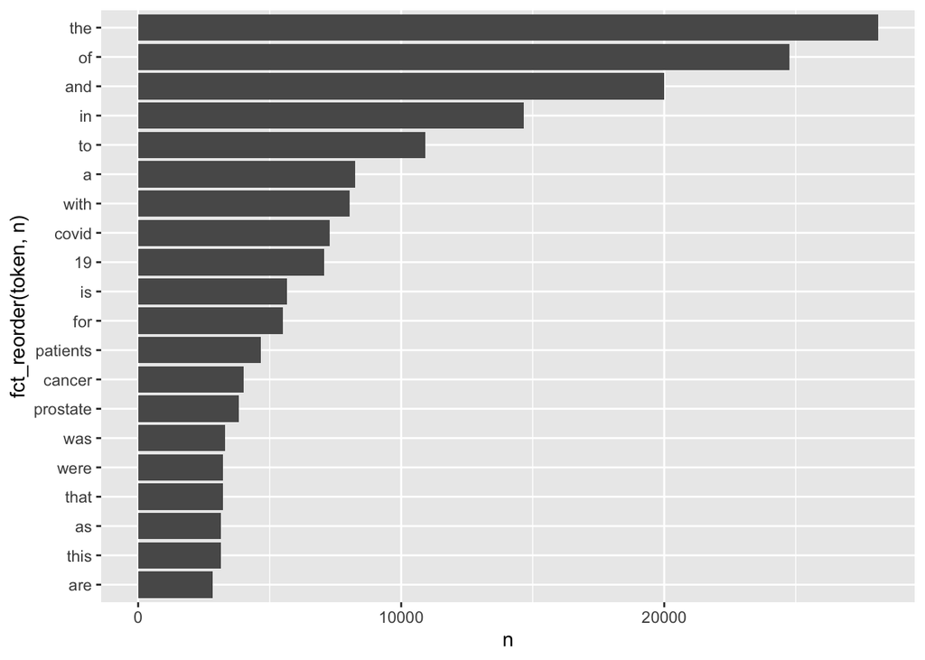

```r
library(tidytext)
library(ggplot2)
library(forcats)
tm <- read_csv("https://raw.githubusercontent.com/USCbiostats/data-science-data/master/03_pubmed/pubmed.csv")
tm %>%
  unnest_tokens(output=token, input=abstract) %>%
  count(token, sort = TRUE) %>%
  top_n(n=20, wt= n) %>%
  ggplot(aes(x=n, y=fct_reorder(token,n))) +
  geom_col()
```

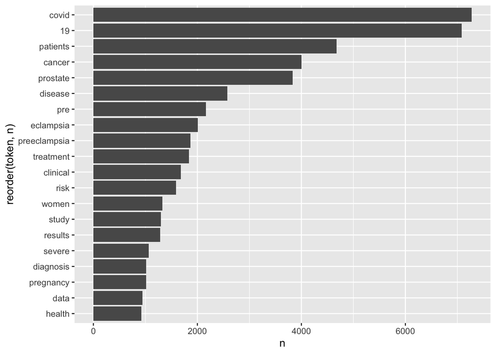

```r
tm %>%
  unnest_tokens(output=token, input=abstract) %>%
  anti_join(stop_words, by = c("token"="word")) %>%
  count(token, sort = TRUE) %>%
  top_n(n=20, wt= n) %>%
  ggplot(aes(x=n, y=reorder(token,n))) +
  geom_col()
```

```r
bigram <- tm %>%
  unnest_tokens(token, abstract) %>%
  filter(!(token %in% stop_words$word)) %>%
  group_by(term) %>%
  count(token, sort = TRUE) %>%
  top_n(5, n) %>%
  arrange(term, desc(n))
knitr::kable(bigram, caption = "The 5 most common tokens for each search term")
```

The 5 most common tokens for each search term

| term | token | n |
| --- | --- | --- |
| covid | covid | 7275 |
| covid | 19 | 7035 |
| covid | patients | 2293 |
| covid | disease | 943 |
| covid | pandemic | 800 |
| cystic fibrosis | fibrosis | 867 |
| cystic fibrosis | cystic | 862 |
| cystic fibrosis | cf | 625 |
| cystic fibrosis | patients | 586 |
| cystic fibrosis | disease | 400 |
| meningitis | patients | 446 |
| meningitis | meningitis | 429 |
| meningitis | meningeal | 219 |
| meningitis | csf | 206 |
| meningitis | clinical | 187 |
| preeclampsia | pre | 2038 |
| preeclampsia | eclampsia | 2005 |
| preeclampsia | preeclampsia | 1863 |
| preeclampsia | women | 1196 |
| preeclampsia | pregnancy | 969 |
| prostate cancer | cancer | 3840 |
| prostate cancer | prostate | 3832 |
| prostate cancer | patients | 934 |
| prostate cancer | treatment | 926 |
| prostate cancer | disease | 652 |

Most of the frequent words are stop words. After remove the stop words, covid, 19 and patients are the top three frequent words. After removing the stop words, the 5 most common words for ‘covid’ are ‘19’, ‘covid’, ‘disease’, ‘pandemic’ and ‘patients’; for ‘cyctic fibrosis’ are ‘cf’, ‘cystic’, ‘disease’, ‘fibrosis’ and ‘patients’; for ‘meningitis’ are ‘clinical’, ‘csf’, ‘meningeal’, ‘meningitis’ and ‘patients’; for ‘preeclampsia’ are ‘eclampsia’, ‘pre’, ‘preeclampsia’, ‘pregnancy’ and ‘women’; for ‘prostate cancer’ are ‘cancer’, ‘disease’, ‘patients’, ‘prostate’ and ‘treatment’.

#### 2

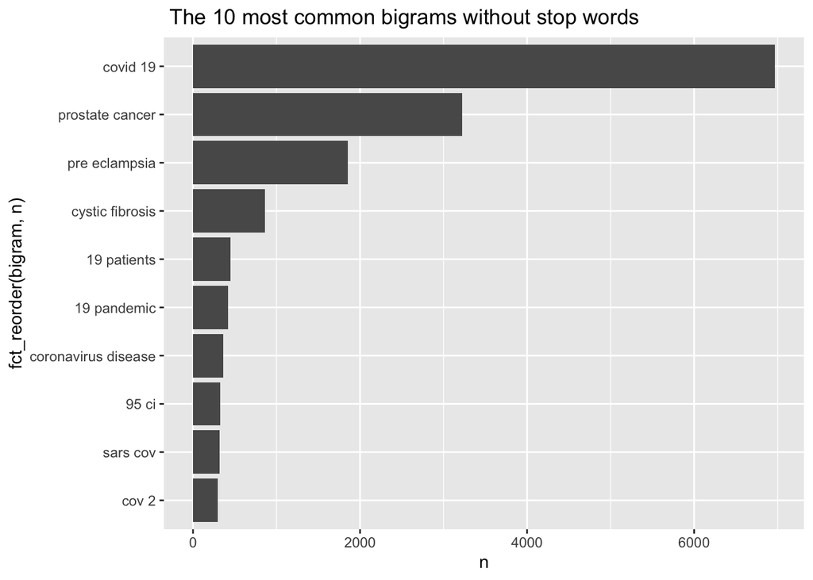

```r
tm2 <- tm %>%
  unnest_ngrams(token, abstract, n = 2) %>%
  separate(token, into = c("word1", "word2"), sep = " ") %>%
  anti_join(tidytext::stop_words, by = c("word1" = "word")) %>%
  anti_join(tidytext::stop_words, by = c("word2" = "word")) %>%
  unite(bigram, word1, word2, sep = " ")
tm2 %>%
  count(bigram, sort = TRUE) %>%
  top_n(10, n) %>%
  ggplot(aes(x = n, y = fct_reorder(bigram, n)))+
  geom_col()+
  ggtitle(" The 10 most common bigrams without stop words")
```

The 10 most common bigram is ‘covid 19’, ‘prostate cancer’, ‘pre eclampsia’, ‘cystic fibrosis’, ‘19 patients’, ‘19 pandemic’, ‘coronavirus disease’, ‘95 ci’, ‘sars cov’ and ‘cov 2’.

#### 3

```r
tf_idf <- tm %>%
  unnest_tokens(token, abstract) %>%
  filter(!(token %in% stop_words$word)) %>%
  group_by(term) %>%
  count(token, sort = TRUE) %>%
  bind_tf_idf(token, term, n) %>%
  arrange(desc(tf_idf)) %>%
  top_n(5, n)%>%
  arrange(term, desc(tf_idf))
knitr::kable(list(tf_idf, bigram))
```

| term | token | n | tf | idf | tf_idf |
| --- | --- | --- | --- | --- | --- |
| covid | covid | 7275 | 0.0646920 | 1.6094379 | 0.1041177 |
| covid | pandemic | 800 | 0.0071139 | 1.6094379 | 0.0114494 |
| covid | 19 | 7035 | 0.0625578 | 0.0000000 | 0.0000000 |
| covid | patients | 2293 | 0.0203902 | 0.0000000 | 0.0000000 |
| covid | disease | 943 | 0.0083855 | 0.0000000 | 0.0000000 |
| cystic fibrosis | cf | 625 | 0.0234126 | 0.9162907 | 0.0214528 |
| cystic fibrosis | fibrosis | 867 | 0.0324780 | 0.5108256 | 0.0165906 |
| cystic fibrosis | cystic | 862 | 0.0322907 | 0.5108256 | 0.0164949 |
| cystic fibrosis | patients | 586 | 0.0219517 | 0.0000000 | 0.0000000 |
| cystic fibrosis | disease | 400 | 0.0149841 | 0.0000000 | 0.0000000 |
| meningitis | meningitis | 429 | 0.0163959 | 1.6094379 | 0.0263883 |
| meningitis | meningeal | 219 | 0.0083700 | 1.6094379 | 0.0134709 |
| meningitis | csf | 206 | 0.0078731 | 0.9162907 | 0.0072141 |
| meningitis | patients | 446 | 0.0170457 | 0.0000000 | 0.0000000 |
| meningitis | clinical | 187 | 0.0071470 | 0.0000000 | 0.0000000 |
| preeclampsia | eclampsia | 2005 | 0.0255268 | 1.6094379 | 0.0410837 |
| preeclampsia | preeclampsia | 1863 | 0.0237189 | 1.6094379 | 0.0381741 |
| preeclampsia | pregnancy | 969 | 0.0123369 | 0.5108256 | 0.0063020 |
| preeclampsia | pre | 2038 | 0.0259469 | 0.0000000 | 0.0000000 |
| preeclampsia | women | 1196 | 0.0152269 | 0.0000000 | 0.0000000 |
| prostate cancer | prostate | 3832 | 0.0562950 | 1.6094379 | 0.0906033 |
| prostate cancer | cancer | 3840 | 0.0564125 | 0.0000000 | 0.0000000 |
| prostate cancer | patients | 934 | 0.0137212 | 0.0000000 | 0.0000000 |
| prostate cancer | treatment | 926 | 0.0136036 | 0.0000000 | 0.0000000 |
| prostate cancer | disease | 652 | 0.0095784 | 0.0000000 | 0.0000000 |

| term | token | n |
| --- | --- | --- |
| covid | covid | 7275 |
| covid | 19 | 7035 |
| covid | patients | 2293 |
| covid | disease | 943 |
| covid | pandemic | 800 |
| cystic fibrosis | fibrosis | 867 |
| cystic fibrosis | cystic | 862 |
| cystic fibrosis | cf | 625 |
| cystic fibrosis | patients | 586 |
| cystic fibrosis | disease | 400 |
| meningitis | patients | 446 |
| meningitis | meningitis | 429 |
| meningitis | meningeal | 219 |
| meningitis | csf | 206 |
| meningitis | clinical | 187 |
| preeclampsia | pre | 2038 |
| preeclampsia | eclampsia | 2005 |
| preeclampsia | preeclampsia | 1863 |
| preeclampsia | women | 1196 |
| preeclampsia | pregnancy | 969 |
| prostate cancer | cancer | 3840 |
| prostate cancer | prostate | 3832 |
| prostate cancer | patients | 934 |
| prostate cancer | treatment | 926 |
| prostate cancer | disease | 652 |

Unlike the answers in question 1, ‘19’, ‘patients’ and ‘disease’ do not have TD-IDF value with ‘covid’. Similarly, ‘patients’ and ‘disease’ do not have TD-IDF value with ‘cystic fibrosis’; ‘patients’ and ‘clinical’ do not have TD-IDF with ‘meningitis’; and ‘pre’ and ‘women’ do not have TD-IDF value with ‘preeclampsia’. For search term ‘prostate cancer’, only ‘prostate’ has TD-IDF value.